# Visualizing the DC bikeshare network

Katie Jolly

November 20, 2017

# Setting up the project

DC has a vast and well-used public bike system. There are lots of bike lanes, and even a few protected bikeways to help make biking a more appealing option. In my experience, I can often move around faster on a bike than I can on a metro train, bus, or in a car. In this project I will explore different ways of thinking about the project, pulling from different resources along the way. My initial inspiration to write this project was the paper [Visualizing London’s Bicycle-Hire Scheme](http://openaccess.city.ac.uk/538/) by Jo Wood, Aidan Slingsby, and Jason Dykes. It introduces new (or improved) techniques for visualizing dense transportation networks where simple vertices and edges might not suffice. I wanted to try to adapt this analysis to the specific context of DC, and perhaps broaden it in the future!

Some of the data science topics I’ll attempt to cover are:

- Data wrangling
- Databases
- Data visualization
- Presentation

I’ll try to leave explanations as I go! I’ll also include all of the code in case anything is new or confusing.

# Packages

```r
library(tidyverse) # this includes a variety of packages including ggplot2, tidyr, dplyr, and stringr
library(leaflet) # for interactive maps
library(sp) # configuring geographic data
library(rgdal) # configuring geographic data
library(igraph) # network analysis
library(lubridate) # manipulation time data
# install highcharter
```

# Analysis and visualization

## Data!

I’m starting with just one fiscal quarter (2015 Q1) of data to see how the methods work. At the end I’ll perform the same analysis on a much larger set of data.

```r
dc_bikes_sample_2015Q1 <- read_csv("bikeshare-dplyr/dc_bikes_sample_2015Q1.csv")
```

First let’s take a look at the data we do have.

```r
glimpse(dc_bikes_sample_2015Q1)
```

```
## Observations: 100,000
## Variables: 7
## $ duration          <int> 506730, 653609, 3175761, 432546, 682000, 225...
## $ sdate             <chr> "3/11/2015 7:10", "2/16/2015 11:53", "2/4/20...
## $ sstation          <chr> "Lincoln Park / 13th & East Capitol St NE", ...
## $ edate             <chr> "3/11/2015 7:19", "2/16/2015 12:04", "2/4/20...
## $ estation          <chr> "Columbus Circle / Union Station", "20th St ...
## $ bike_num          <chr> "W20814", "W21528", "W00800", "W21715", "W00...
## $ subscription_type <chr> "Registered", "Registered", "Registered", "R...
```

## Cleaning the data

There are a few inconsistencies that can happen with the data. The first, a zero time-lenth journey, is something we should filter out. These were likely customers who failed to properly get a bike or returned a bike that they realized was not functional. These trips won’t add to our analysis. The second, a zero distance journey, may seem like an error but is likely a valid trip. In this case, the customer likely make a quick loop around and returned a bike to the same docking station. This is a common occurence near the National Mall where tourists may just take the bikes for a quick tour of the area.

### Filtering zero time-length trips

```r
dc_bikes_sample_2015Q1_clean <- dc_bikes_sample_2015Q1 %>%
  mutate(sdate = mdy_hm(sdate),
         edate = mdy_hm(edate),
         stime = hour(sdate) + minute(sdate)/60,
         etime = hour(edate) + minute(edate)/60,
         duration = ifelse(etime - stime >= 0, etime - stime, 24-stime + etime)) %>%
  filter((duration != 0), !(sstation == estation & duration <= 0.1)) # taking out trips with 0 duration or a very short duration with the same start and end station
```

Out of curiosity, I want to save the failed attempts in case I do an analysis of them later.

```r
failed_attempts <- dc_bikes_sample_2015Q1 %>%
  mutate(sdate = mdy_hm(sdate),
         edate = mdy_hm(edate),
         stime = hour(sdate) + minute(sdate)/60,
         etime = hour(edate) + minute(edate)/60,
         duration = ifelse(etime - stime >= 0, etime - stime, 24-stime + etime)) %>%
  group_by(sstation) %>%
  summarize(prop_failed = sum(duration == 0)/(n() + 20)) %>%
  arrange(desc(prop_failed))

paste0("There were ", nrow(failed_attempts), " failed attempts in this data")
```

[output not shown]

## Duration distributions

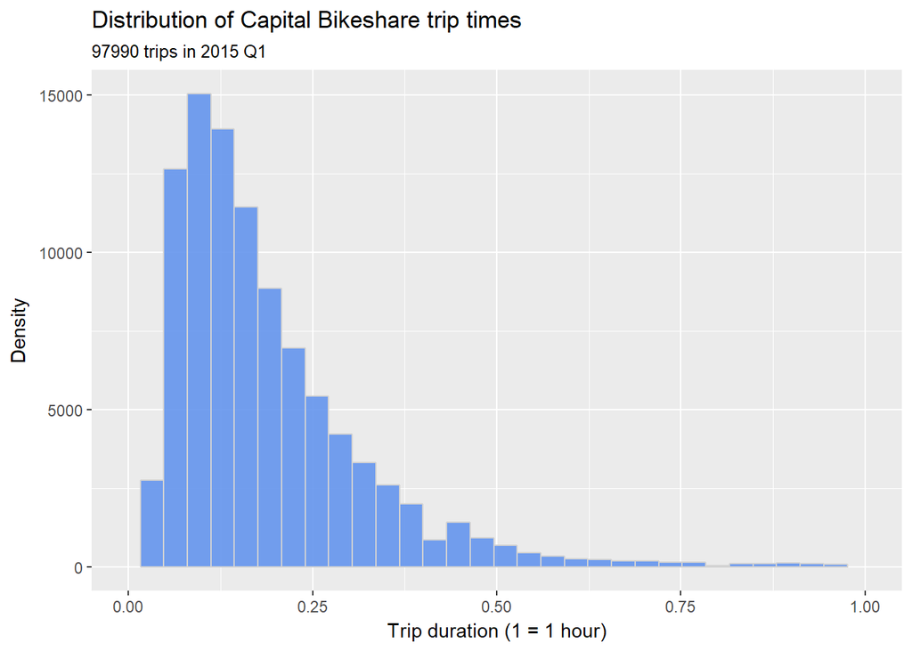

```r
ggplot(dc_bikes_sample_2015Q1_clean,
       aes(x = duration)) +
  geom_histogram(binwidth = 0.032, fill = "cornflowerblue", alpha = 0.9, color = "lightgray") +
  xlim(0, 1) +
  labs(title = "Distribution of Capital Bikeshare trip times",
       subtitle = "97990 trips in 2015 Q1",
       y = "Density",
       x = "Trip duration (1 = 1 hour)")
```